# DATA621 Homework3 - Crime Ratings

Jonathan Hernandez

June 20, 2018

## Introduction

- This assignment looks at crime information on various neighborhood for a major

city. There are several variables and the goal is to come up with a binary logistic

regression model that can predict whether a particular neighborhood will be at

risk for high crime levels. I will examine a few models and use the best criteria

based on statistics such as ROC curves/AUC (Area under the curve) values and

confusion matricies for each model. The model with the best performance and accuracy

will be considered. Finally, the model will be evaluated using the training data

and then I will make predictions based using the evaluation data set.

## Data Preparation

- Let’s first load the dataset and examine the structure and summary of the dataset
- Summary:

```
##        zn             indus             chas              nox
##  Min.   :  0.00   Min.   : 0.460   Min.   :0.00000   Min.   :0.3890
##  1st Qu.:  0.00   1st Qu.: 5.145   1st Qu.:0.00000   1st Qu.:0.4480
##  Median :  0.00   Median : 9.690   Median :0.00000   Median :0.5380
##  Mean   : 11.58   Mean   :11.105   Mean   :0.07082   Mean   :0.5543
##  3rd Qu.: 16.25   3rd Qu.:18.100   3rd Qu.:0.00000   3rd Qu.:0.6240
##  Max.   :100.00   Max.   :27.740   Max.   :1.00000   Max.   :0.8710
##        rm             age              dis              rad
##  Min.   :3.863   Min.   :  2.90   Min.   : 1.130   Min.   : 1.00
##  1st Qu.:5.887   1st Qu.: 43.88   1st Qu.: 2.101   1st Qu.: 4.00
##  Median :6.210   Median : 77.15   Median : 3.191   Median : 5.00
##  Mean   :6.291   Mean   : 68.37   Mean   : 3.796   Mean   : 9.53
##  3rd Qu.:6.630   3rd Qu.: 94.10   3rd Qu.: 5.215   3rd Qu.:24.00
##  Max.   :8.780   Max.   :100.00   Max.   :12.127   Max.   :24.00
##       tax           ptratio         black            lstat
##  Min.   :187.0   Min.   :12.6   Min.   :  0.32   Min.   : 1.730
##  1st Qu.:281.0   1st Qu.:16.9   1st Qu.:375.61   1st Qu.: 7.043
##  Median :334.5   Median :18.9   Median :391.34   Median :11.350
##  Mean   :409.5   Mean   :18.4   Mean   :357.12   Mean   :12.631
##  3rd Qu.:666.0   3rd Qu.:20.2   3rd Qu.:396.24   3rd Qu.:16.930
##  Max.   :711.0   Max.   :22.0   Max.   :396.90   Max.   :37.970
##       medv           target
##  Min.   : 5.00   Min.   :0.0000
##  1st Qu.:17.02   1st Qu.:0.0000
##  Median :21.20   Median :0.0000
##  Mean   :22.59   Mean   :0.4914
##  3rd Qu.:25.00   3rd Qu.:1.0000
##  Max.   :50.00   Max.   :1.0000
```

- Structure (number of rows and columns, variable type such as int, factor etc):

```
## 'data.frame':    466 obs. of  14 variables:
##  $ zn     : num  0 0 0 30 0 0 0 0 0 80 ...
##  $ indus  : num  19.58 19.58 18.1 4.93 2.46 ...
##  $ chas   : int  0 1 0 0 0 0 0 0 0 0 ...
##  $ nox    : num  0.605 0.871 0.74 0.428 0.488 0.52 0.693 0.693 0.515 0.392 ...
##  $ rm     : num  7.93 5.4 6.49 6.39 7.16 ...
##  $ age    : num  96.2 100 100 7.8 92.2 71.3 100 100 38.1 19.1 ...
##  $ dis    : num  2.05 1.32 1.98 7.04 2.7 ...
##  $ rad    : int  5 5 24 6 3 5 24 24 5 1 ...
##  $ tax    : int  403 403 666 300 193 384 666 666 224 315 ...
##  $ ptratio: num  14.7 14.7 20.2 16.6 17.8 20.9 20.2 20.2 20.2 16.4 ...
##  $ black  : num  369 397 387 375 394 ...
##  $ lstat  : num  3.7 26.82 18.85 5.19 4.82 ...
##  $ medv   : num  50 13.4 15.4 23.7 37.9 26.5 5 7 22.2 20.9 ...
##  $ target : int  1 1 1 0 0 0 1 1 0 0 ...
```

- Transform tax and rad variables numberic instead of integer for computation

such as computing correlation between attributes. Later, we wil change the target

and chas attributes to be factors instead of integers so they can be labeled properly.

- The summary of the dataset shows that there are no missing values and besides

the response variable target and the explanatory variable chas, all others are of

the numeric type.

## Data Exploration

- Let us make some plots like histograms and see how each variable behaves. Also,

median crime rate.

- Histograms of each variable

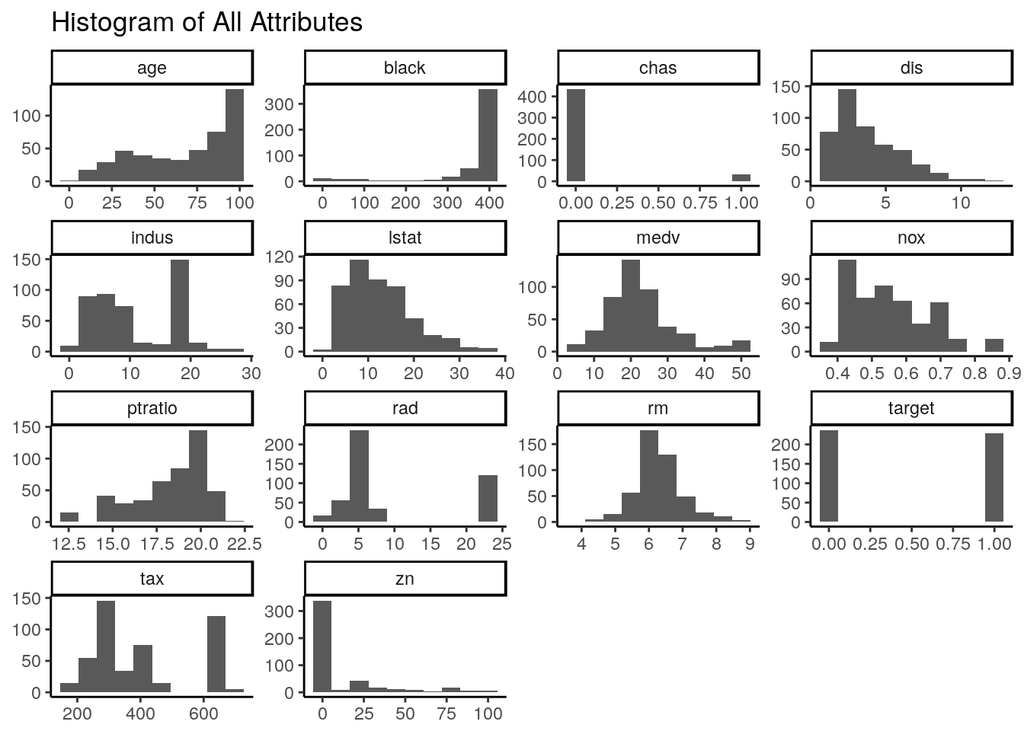

- There appears to be serveral outliers in most of the variables but we will keep them for

now and use them in our models.

- Also let us see how well our data is correlated along with one another. I will

create a correlation table to see the correlation coefficients against each pair

of attributes. This will be useful for one of the models to be built later on.

```
##                 zn      indus        nox         rm        age        dis
## zn       1.0000000 -0.5382664 -0.5170452  0.3198141 -0.5725805  0.6601243
## indus   -0.5382664  1.0000000  0.7596301 -0.3927118  0.6395818 -0.7036189
## nox     -0.5170452  0.7596301  1.0000000 -0.2954897  0.7351278 -0.7688840
## rm       0.3198141 -0.3927118 -0.2954897  1.0000000 -0.2328125  0.1990158
## age     -0.5725805  0.6395818  0.7351278 -0.2328125  1.0000000 -0.7508976
## dis      0.6601243 -0.7036189 -0.7688840  0.1990158 -0.7508976  1.0000000
## rad     -0.3154812  0.6006284  0.5958298 -0.2084457  0.4603143 -0.4949919
## tax     -0.3192841  0.7322292  0.6538780 -0.2969343  0.5121245 -0.5342546
## ptratio -0.3910357  0.3946898  0.1762687 -0.3603471  0.2554479 -0.2333394
## black    0.1794150 -0.3581356 -0.3801549  0.1326676 -0.2734677  0.2938441
## lstat   -0.4329925  0.6071102  0.5962426 -0.6320245  0.6056200 -0.5075280
## medv     0.3767171 -0.4961743 -0.4301227  0.7053368 -0.3781560  0.2566948
##                rad        tax    ptratio      black      lstat       medv
## zn      -0.3154812 -0.3192841 -0.3910357  0.1794150 -0.4329925  0.3767171
## indus    0.6006284  0.7322292  0.3946898 -0.3581356  0.6071102 -0.4961743
## nox      0.5958298  0.6538780  0.1762687 -0.3801549  0.5962426 -0.4301227
## rm      -0.2084457 -0.2969343 -0.3603471  0.1326676 -0.6320245  0.7053368
## age      0.4603143  0.5121245  0.2554479 -0.2734677  0.6056200 -0.3781560
## dis     -0.4949919 -0.5342546 -0.2333394  0.2938441 -0.5075280  0.2566948
## rad      1.0000000  0.9064632  0.4714516 -0.4463750  0.5031013 -0.3976683
## tax      0.9064632  1.0000000  0.4744223 -0.4425059  0.5641886 -0.4900329
## ptratio  0.4714516  0.4744223  1.0000000 -0.1816395  0.3773560 -0.5159153
## black   -0.4463750 -0.4425059 -0.1816395  1.0000000 -0.3533659  0.3300286
## lstat    0.5031013  0.5641886  0.3773560 -0.3533659  1.0000000 -0.7358008
## medv    -0.3976683 -0.4900329 -0.5159153  0.3300286 -0.7358008  1.0000000
```

## Build Models

- I will use the training data to build at least 3 different binary logistic regression

models using different models and techniques.

- Let’s first with the trivial easiest model; include all variables to predict

if a city will be above or below the crime rate. No variable elimination is done.

### Model 1

```
##
## Call:
## glm(formula = target ~ zn + indus + chas + nox + rm + age + dis +
##     rad + tax + ptratio + black + lstat + medv, family = "binomial",
##     data = crime)
##
## Deviance Residuals:
##     Min       1Q   Median       3Q      Max
## -2.2854  -0.1372  -0.0017   0.0020   3.4721
##
## Coefficients:
##               Estimate Std. Error z value Pr(>|z|)
## (Intercept) -36.839521   7.028726  -5.241 1.59e-07 ***
## zn           -0.061720   0.034410  -1.794 0.072868 .
## indus        -0.072580   0.048546  -1.495 0.134894
## chas1         1.032352   0.759627   1.359 0.174139
## nox          50.159513   8.049503   6.231 4.62e-10 ***
## rm           -0.692145   0.741431  -0.934 0.350548
## age           0.034522   0.013883   2.487 0.012895 *
## dis           0.765795   0.234407   3.267 0.001087 **
## rad           0.663015   0.165135   4.015 5.94e-05 ***
## tax          -0.006593   0.003064  -2.152 0.031422 *
## ptratio       0.442217   0.132234   3.344 0.000825 ***
## black        -0.013094   0.006680  -1.960 0.049974 *
## lstat         0.047571   0.054508   0.873 0.382802
## medv          0.199734   0.071022   2.812 0.004919 **
## ---
## Signif. codes:  0 '***' 0.001 '**' 0.01 '*' 0.05 '.' 0.1 ' ' 1
##
## (Dispersion parameter for binomial family taken to be 1)
##
##     Null deviance: 645.88  on 465  degrees of freedom
## Residual deviance: 186.15  on 452  degrees of freedom
## AIC: 214.15
##
## Number of Fisher Scoring iterations: 9
```

### Model 2

- The second model is done using backward elimination; from the above this eliminates the

following variables due to having high p-values. The variables selected are

the ones that have low p-values below 0.05 are significant.

```
##
## Call:
## glm(formula = target ~ nox + age + dis + rad + tax + ptratio +
##     medv, family = "binomial", data = crime)
##
## Deviance Residuals:
##      Min        1Q    Median        3Q       Max
## -2.01059  -0.19744  -0.01371   0.00402   3.06424
##
## Coefficients:
##               Estimate Std. Error z value Pr(>|z|)
## (Intercept) -36.824228   5.858405  -6.286 3.26e-10 ***
## nox          42.338378   6.639207   6.377 1.81e-10 ***
## age           0.031882   0.010693   2.982 0.002867 **
## dis           0.429555   0.171849   2.500 0.012433 *
## rad           0.701767   0.139426   5.033 4.82e-07 ***
## tax          -0.008237   0.002534  -3.250 0.001153 **
## ptratio       0.376575   0.108912   3.458 0.000545 ***
## medv          0.093653   0.033556   2.791 0.005255 **
## ---
## Signif. codes:  0 '***' 0.001 '**' 0.01 '*' 0.05 '.' 0.1 ' ' 1
##
## (Dispersion parameter for binomial family taken to be 1)
##
##     Null deviance: 645.88  on 465  degrees of freedom
## Residual deviance: 203.45  on 458  degrees of freedom
## AIC: 219.45
##
## Number of Fisher Scoring iterations: 9
```

### Model 3

- The third model is to use the idea of correlation to filter out variables with

high correlation using a cutoff point of 0.75. By using this, we can see if we can

get a binary classification model that can have high accuracy of calculating if a

particular neighborhood will be targeted for a high crime rate or not. Variables that

are highly correlated

```
## [1] "Variables to be used:"
```

```
##  [1] "zn"      "nox"     "age"     "dis"     "tax"     "ptratio" "black"
##  [8] "lstat"   "medv"    "target"
```

```
##
## Call:
## glm(formula = target ~ zn + nox + age + dis + tax + ptratio +
##     black + lstat + medv, family = "binomial", data = crime_subset)
##
## Deviance Residuals:
##      Min        1Q    Median        3Q       Max
## -2.26039  -0.31877  -0.01099   0.22687   3.08518
##
## Coefficients:
##               Estimate Std. Error z value Pr(>|z|)
## (Intercept) -29.745688   5.154374  -5.771 7.88e-09 ***
## zn           -0.068459   0.029039  -2.357   0.0184 *
## nox          36.897169   5.473339   6.741 1.57e-11 ***
## age           0.021283   0.009663   2.203   0.0276 *
## dis           0.776376   0.190603   4.073 4.64e-05 ***
## tax           0.002733   0.001515   1.804   0.0713 .
## ptratio       0.228694   0.101724   2.248   0.0246 *
## black        -0.011202   0.005160  -2.171   0.0299 *
## lstat         0.050236   0.042441   1.184   0.2365
## medv          0.177577   0.036889   4.814 1.48e-06 ***
## ---
## Signif. codes:  0 '***' 0.001 '**' 0.01 '*' 0.05 '.' 0.1 ' ' 1
##
## (Dispersion parameter for binomial family taken to be 1)
##
##     Null deviance: 645.88  on 465  degrees of freedom
## Residual deviance: 240.50  on 456  degrees of freedom
## AIC: 260.5
##
## Number of Fisher Scoring iterations: 8
```

## Model 4

- We will use the glmnet package to do feature selection on the crime dataset

and retrieve the variables most relevant to predict the response variable target.

I’m also using the concept of LASSO regularization that finds good regularization

coefficent to prevent overfitting and puts a constraint on the sum of the feature values.

Adding an extra term in the logistic regression (or linear regression) is common

and usually involves adding a coefficent lambda $\lambda$ the higher the $\lambda$

value is, the more bias but less overfitting.

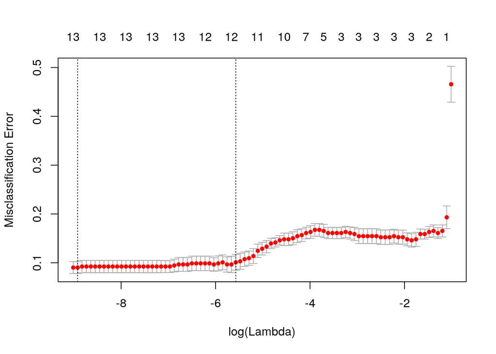

```
##        s0
## -23.56424
```

```
##           zn        indus         chas          nox           rm
## -0.024779049 -0.045288486  0.801675776 30.822861720  0.000000000
##          age          dis          rad          tax      ptratio
##  0.018486449  0.284893698  0.322488326 -0.002738699  0.209788193
##        black        lstat         medv
## -0.006687892  0.015041375  0.077567577
```

```
## [1] -864.5177
```

### Summary of the built models

- Starting with Model 1 that is to include all variables based on

the coefficents is showing that the variable nox (nitrogen oxide concentration)

has the most influence out of the other variables and says that for

every concentration, all constants held constant, the probability will greatly increase

and will be more likley for that town to have a high crime level.

- The second model which uses backward elimination has coefficents that have good

significant p-values and has a higher AIC value. Like the first model, the

coefficent for nox is high and seems to be the main variable that holds the most

weight when computing the probability of a city having a high crime level. The only

coefficent that is negative is the tax variable which means for all other variables

held constant and for every 1% increase in tax rate, the probability of that city

being a high crime level city decreases by a factory of 0.0082.

- The third model uses correlation matricies and the correlation threshold of 0.75

and uses the 2nd least variables. The AIC value is higher than the first two models.

Coefficents are similar and took less time to converge to a solution (see the

Fisher Scoring iterations in the summary of model 3).

- Model 4 the final model uses the concept of LASSO (Least absolute shrinkage

and selection operator) to select variables and prevent the model from overfitting

the data using the concept of regularization to penalize variables that would

overfit the data. Variable coefficents are the similar but the rm (average number

of rooms per dwelling) is 0 and is the only variable not included in the model.

The AIC is low as well which makes it a good candidate as well for picking a good

model.

## Selecting Model

- After looking at each model, I decided to go with the one with the lowest AIC

model as that rubric is used for doing feature selection and an appropriate model.

| probabilities | aboveCrimeLevel |
| --- | --- |
| 0.0455447592 | no |
| 0.3457725904 | no |
| 0.3879449964 | no |
| 0.5105564127 | yes |
| 0.0702501558 | no |
| 0.0970692405 | no |
| 0.1279231963 | no |
| 0.0195159196 | no |
| 0.0117496882 | no |
| 0.0079922804 | no |

[output cut: 30 more lines]